# Intro

**Description**:

This script selects a parsimonious, uncorrelated feature set. While RF is robust to collinearity, studies suggest it does better with an uncorrelated & parsimonious featureset.

I wanted to use a semi-manual selection process, rather than a fully-automated, because honestly *feature selection is part science and part art*. This script explains my process on a subset of my data (my data and featureset were hugggeeee – I had to run feature selection on a high performance computer).

**Inputs**:

Training data with a variable called “block”, which divides my data into 9 spatio-temporal folds

**Steps**:

1. run cross-validated recursive feature elimination (CV-RFE) to get the top feature

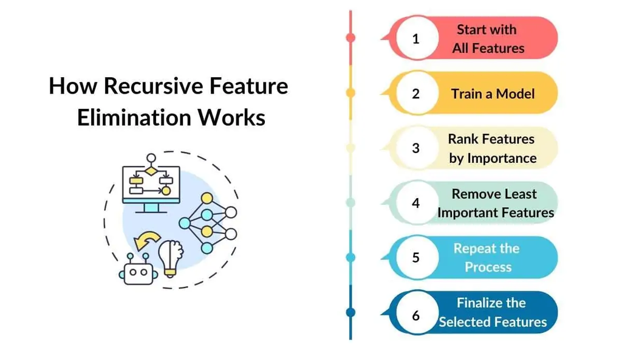

Link to mlr3 feature selection package, with more explanations: https://mlr3fselect.mlr-org.com/

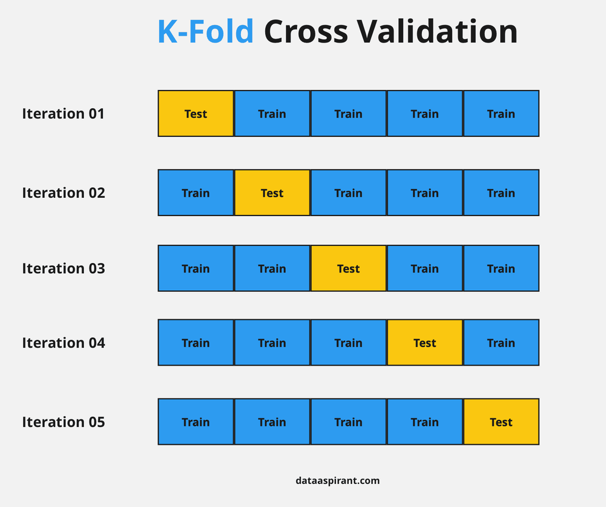

2. remove all features that are >0.88 correlated with the top feature
3. run CV-RFE again to get the 2nd top feature
4. remove features correlated with it
5. etc etc until I’ve removed all pairwise correlations
6. pick the top n features, stopping when performance gains from more features plateaus

**Outputs**: results of cv-rfe runs

# Setup

```r
# Load packages
library(tidyverse)
library(data.table)
library(car)
library(mlr3spatiotempcv)
library(mlr3learners)
library(mlr3fselect)
library(mlr3pipelines)
library(parallelly)
library(future)
library(here)

# set number of cores to use to 3 out of my laptop's 8
parallelly::availableCores()
```

```
## system
##      8
```

```r
w <- 3
```

```r
# Read in training data (this is a subset - I had 140k training points for my model)
train <- read_csv(here("feature_selection_for_lab/data/train_small.csv"))

# featureset (also a subset - I considered 57 features for my model)
full_featureset <- c("VV","VH","VVVH_rt",
                     "AWEI","TCW","NDMI1","NDRE","NDVI","TCG","OSAVI")
```

# Create function to run CV-RFE

I set up my RF classification task for cross-validated recursive feature elimination (CV-RFE). Decisions I had to make include:

- loss function: I use AUC
- importance: I use impurity, but I could have used permutation
- num.trees = 500 (higher = more stable variable importance estimates, but takes longer to compute)
- max.depth = 10 (higher = more complex. 10 is still pretty-high end, and hopefully helps with efficiency)

See all RF tuning parameters [here](https://mlr3learners.mlr-org.com/reference/mlr_learners_classif.ranger.html).

```r
cv_rfe <- function(df, feats, runnum, reps=1){

  all_rfe <- list()  # store each repetition

  for(r in seq_len(reps)){

    # different seed per repetition
    set.seed(123 + r - 1)

    # set up task
    task <-
      df |>
      dplyr::select(all_of(feats), type, block) |>
      dplyr::mutate(type=as.factor(type)) |>
      mlr3::as_task_classif(target="type",
                            positive="wet")

    # instantiate leave-one-block-out resampling method
    rsmp_lobo <- mlr3::rsmp("loo")
    task$set_col_roles("block", add_to = "group")
    rsmp_lobo$instantiate(task)

    # limit task to our predictors
    task <- task$select(feats)

    # check that each block will be used as a test set once
    stopifnot(rsmp_lobo$iters == n_distinct(df$block))

    # setup parallel processing
    future::plan("multisession", workers=w)

    print(paste("NUMBER OF PARALLEL PROCESSES:", w))

    # specify algorithm - here I use random forest
    lrn_rf = mlr3::lrn("classif.ranger",
                       predict_type = "prob",
                       importance = "impurity",
                       num.trees = 500,
                       max.depth = 10)

    # specify feature selection method
    fselector = fs("rfecv",
                   feature_number = 1,  # n features removed in each elimination
                   n_features = 1)      # selection stops there's n_features left

    # set up the feature selection process
    instance = fsi(
      task =  task,
      learner = lrn_rf,               # our RF learner
      resampling = rsmp_lobo,         # our custom leave-one-block-out resampling strategy
      measure = msr("classif.auc"),   # feature selection will aim to optimize AUC
      terminator = trm("none"),
      store_benchmark_result = FALSE, # had to set this to F for memory efficiency
      store_models = TRUE             # needed to assess RFE, when the above is F
    )

    # execute feature selection process
    fselector$optimize(instance)

    # get the RFE archive
    rfe = as.data.table(instance$archive)[!is.na(iteration), ] |>
      mutate(
        n_feat = lengths(features),
        importance = sapply(importance, function(x) paste(x, collapse = ",")),
        features   = sapply(features, function(x) paste(x, collapse = ",")),
        n_features = as.integer(sapply(n_features, function(x) paste(x, collapse = ","))),
        rep = r
      )

    all_rfe[[r]] <- rfe

  }

  # combine repetitions
  rfe_all <- data.table::rbindlist(all_rfe)

  # save to disk, for our records
  write_csv(rfe_all, here(paste0("feature_selection_for_lab/data/rfe_results/rfe", runnum,".csv")))

  return(rfe_all)
}
```

# Create helper functions for analysis

### Function to find features that are correlated > 0.88

The 0.88 correlation threshold was arbitrary

```r
find_corr <- function(dat, featureset, var){
  cor_mat <- dat |>
    dplyr::select(all_of(featureset)) |>
    cor()

  cor_vals <- cor_mat[, var]

  names(cor_vals)[
    abs(cor_vals) > 0.88 &
      names(cor_vals) != var
  ]
}
```

### Function to print “votes”

This tallies the feature rankings across folds

```r
print_votes <- function(rfe, n){

  # get feature names from this rfe run
  feats <- colnames(rfe)[colnames(rfe) %in% full_featureset]

  # get n_feat where a specified feature becomes active
  rfe_switch <- rfe |>
      select(all_of(feats), classif.auc, n_feat, iteration) |>
      tidyr::pivot_longer(
        cols = all_of(feats),
        names_to = "feature",
        values_to = "active"
      ) |>
     arrange(iteration, n_feat) |>
     group_by(iteration, feature) |>
     mutate(
        switched = !lag(active, default = FALSE) & active
     ) |>
     filter(switched)

  rfe_votes <- rfe_switch |>
     filter(n_feat <= n) |>
     group_by(feature, rank=n_feat) |>
     summarize(n_folds = n(), .groups = "drop") |>
     arrange(rank, desc(n_folds))

  return(rfe_votes)
}
```

### Function to visualize cv-rfe results

```r
# rfe: stored output of the cv_rfe function
# feats: vector of variable names, if you want to see where along the process they appear
# print_nfeat: print average auc at a specified n_feat
plot_nfeat <- function(rfe, feats=c(NULL), print_nfeat = NULL, reps="no"){

  plot_title <- deparse(substitute(rfe))

  # mean auc across folds:
  rfe_summary <- rfe |>
    group_by(n_feat) |>
    summarize(mean_auc = mean(classif.auc))

  # plot average model performance vs n_features (average auc across folds)
  p <- ggplot() +
    geom_line(data=rfe, aes(x=n_feat, y=classif.auc, group=interaction(iteration, rep)), color="grey") +
    geom_line(data=rfe_summary, aes(x=n_feat, y=mean_auc), color="black") +
    geom_point(data=rfe_summary, aes(x=n_feat, y=mean_auc), color="black") +
    labs(x = "Number of Features",
         title = plot_title,
         caption = "Each grey line is a hold-out fold. Black line is the average.") +
    theme_minimal() +
    theme(
      axis.title = ggplot2::element_text(size = 16),
      axis.text  = ggplot2::element_text(size = 14),
      plot.title = ggplot2::element_text(size = 18, face = "bold"),
      legend.title = ggplot2::element_text(size = 14),
      legend.text  = ggplot2::element_text(size = 12)
    )

  # visualize how a specified feature(s) helps/hurts each fold
  if(!is.null(feats)){

    # get n_feat where a specified feature becomes active
    rfe_var <- rfe |>
        select(all_of(feats), classif.auc, n_feat, iteration) |>
        tidyr::pivot_longer(
          cols = all_of(feats),
          names_to = "feature",
          values_to = "active"
        ) |>
       arrange(iteration, n_feat) |>
       group_by(iteration, feature) |>
       mutate(
          switched = !lag(active, default = FALSE) & active
       ) |>
       filter(switched)

    p <- p +
      geom_point(data=rfe_var, aes(x=n_feat, y=classif.auc, color=feature))
  }

  # print mean auc at a specified n_feat
  if(!is.null(print_nfeat)){

    auc_at_nfeat <- rfe_summary |> filter(n_feat == print_nfeat)

    p <- p + geom_text(data=auc_at_nfeat,
                       aes(x=n_feat, y=mean_auc, label=sprintf("%.2f",round(mean_auc, 2))),
                       vjust=-1)

  }

  return(p)
}
```

# Running my process

#### Run #1

Run cv-rfe on the full featureset

```r
# (with 9 folds and 10 features, this creates 10 x 9 models)
rfe1 <- cv_rfe(train, full_featureset, 1)
```

Print the top feature in every fold

```r
print_votes(rfe1, 1)
```

```
## # A tibble: 1 × 3
##   feature  rank n_folds
##   <chr>   <dbl>   <int>
## 1 AWEI        1       9
```

AWEI is the unanimous winner.

Now let’s see visualize the number of features vs accuracy.

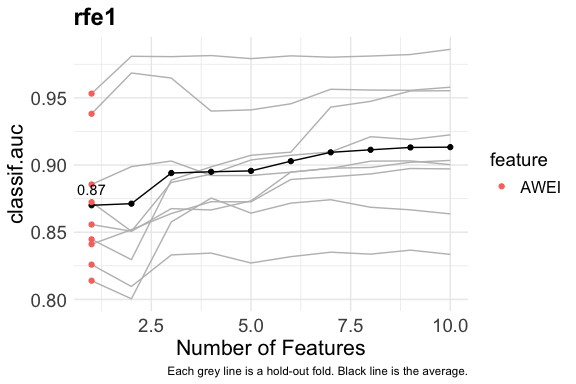

```r
plot_nfeat(rfe1, "AWEI", print_nfeat=1)
```

I know, there’s a lot going on in this figure. It’s showing how each cross-validation iteration (grey line) eliminated features (the last-standing feature is on the left, an all-feature model is on the right), and the accuracy of that iteration’s featureset on its hold-out fold. I highlighted where AWEI ranks in each iteration. Soooo this is saying that a model with only AWEI has an average AUC of 0.87 across folds. Not bad…

Now let’s remove any feature that is highly correlated (> 0.88) with AWEI.

```r
find_corr(train, full_featureset, var="AWEI")
```

```
## [1] "TCW"
```

Ok TCW is correlated with AWEI, so we’ll remove it. But just out of curiousity, what was TCW’s ranking in each fold, in the initial cv-rfe?

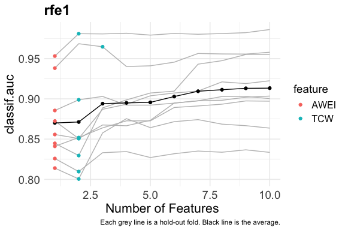

```r
plot_nfeat(rfe1, c("AWEI", "TCW"))
```

2nd! And it doesn’t really seem to help at all. I suspect the model is overfitting to these two features.

Let’s remove TCW from the featureset, then run cv-rfe again to see if the feature importances or rankings change significantly. Maybe NDMI1 will become more important, etc.

```r
featureset2 <- full_featureset |> setdiff("TCW")
```

#### Run #2

Run cv-rfe on the featureset without TCW

```r
# (this creates 9 x 9 models)
rfe2 <- cv_rfe(train, featureset2, 2)
```

Print the top 2 features from this cv-rfe run

```r
print_votes(rfe2, 2)
```

```
## # A tibble: 2 × 3
##   feature  rank n_folds
##   <chr>   <dbl>   <int>
## 1 AWEI        1       9
## 2 NDRE        2       9
```

Ok, again it’s unanimous: AWEI and NDRE are the top feature in every fold. Let’s visualize it.

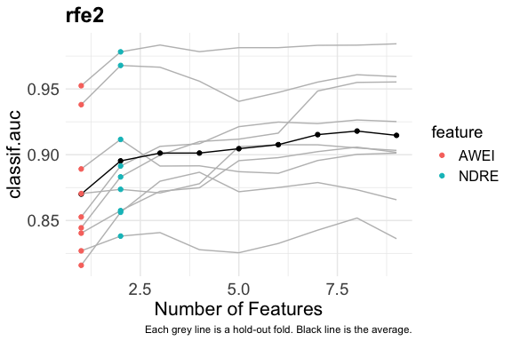

```r
plot_nfeat(rfe2, c("AWEI", "NDRE"))
```

Wow, now our 2nd var (NDRE) actually helps the model! Yay for evidence that removing correlated features actually helps :)

Ok, is anything correlated with NDRE? Nope!

```r
find_corr(train, featureset2, var="NDRE")
```

```
## character(0)
```

So, then let’s go ahead and pick a 3rd variable.

```r
print_votes(rfe2, 3)
```

```
## # A tibble: 3 × 3
##   feature  rank n_folds
##   <chr>   <dbl>   <int>
## 1 AWEI        1       9
## 2 NDRE        2       9
## 3 OSAVI       3       9
```

Ok, OSAVI is the unanimous 3rd pick. Let’s visualize how it helps performance across folds.

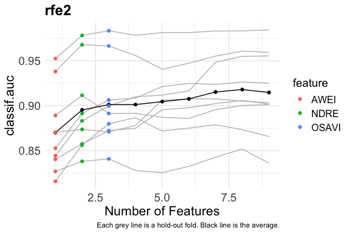

```r
plot_nfeat(rfe2, c("AWEI", "NDRE", "OSAVI"))
```

Hmm, OSAVI is really helpful in a few folds. It’s actually a little unhelpful in a couple though, I wonder why those iterations chose it.

In any case, let’s see if anything is correlated with it

```r
find_corr(train, featureset2, var="OSAVI")
```

```
## [1] "NDVI"
```

Ok NDVI is correlated with OSAVI. Let’s remove it and run it back.

```r
featureset3 <- featureset2 |> setdiff("NDVI")
```

#### Run #3

Run cv-rfe on the featureset without TCW or NDVI

```r
# (this creates 8 x 9 models)
rfe3 <- cv_rfe(train, featureset3, 3)
```

Ok, let’s look at the top 4 variables.

```r
print_votes(rfe3, 4)
```

```
## # A tibble: 4 × 3
##   feature  rank n_folds
##   <chr>   <dbl>   <int>
## 1 AWEI        1       9
## 2 NDRE        2       9
## 3 OSAVI       3       9
## 4 TCG         4       9
```

AWEI, NDRE, and OSAVI remain stable choices in the model. The unanimous fourth pick is TCG.

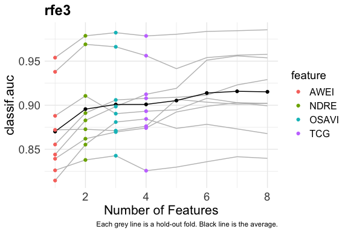

```r
plot_nfeat(rfe3, c("AWEI", "NDRE", "OSAVI", "TCG"))
```

Hmm, the case for TCG is even weaker: a bit helpful in some iterations, a bit unhelpful in others… Honestly I’m not a fan. Let’s take advantage of this non-automated approach and drop it.

```r
featureset4 <- featureset3 |> setdiff("TCG")
```

#### Run #4

```r
# (this creates 7 x 9 models)
rfe4 <- cv_rfe(train, featureset4, 4)
```

And the new 4th pick is….

```r
print_votes(rfe4, 4)
```

```
## # A tibble: 6 × 3
##   feature  rank n_folds
##   <chr>   <dbl>   <int>
## 1 AWEI        1       9
## 2 NDRE        2       9
## 3 OSAVI       3       9
## 4 VV          4       5
## 5 NDMI1       4       2
## 6 VH          4       2
```

A tossup! It’s between NDMI1, VV, and VH. Let’s visualize these three.

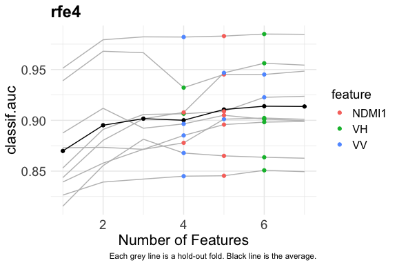

```r
plot_nfeat(rfe4, c("NDMI1", "VV", "VH"))
```

Gosh I can’t decide. Let’s just go with VH, because it has a bit more support in the literature for detecting flooded vegetation.

```r
find_corr(train, featureset4, var="VH")
```

```
## [1] "VV"      "VVVH_rt"
```

Ok, let’s drop VV and VV/VH, and re-run

```r
featureset5 <- featureset4 |> setdiff(c("VV", "VVVH_rt"))
```

#### Run #5

Ok, we’re down to AWEI, NDRE, OSAVI, NDMI1, and VH. We’ve arrived at a featureset with no pairwise correlations - so now we just get to decide how many features we want to include.

```r
# (this creates 5 x 9 models)
rfe5 <- cv_rfe(train, featureset5, 5)
```

Visualize

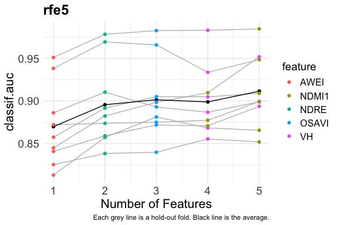

```r
plot_nfeat(rfe5, featureset5)
```

I’m wondering if I should get rid of VH, excluding S1 features from my model. The literature suggests that S1 provides useful complimentary information, but I’m not seeing that here. Maybe S1 data isn’t worth the effort to include… Again, feature selection is an art!

Let’s see what RFE looks like without VH

```r
featureset6 <- featureset5 |> setdiff(c("VH"))
```

#### Run #6

```r
rfe6 <- cv_rfe(train, featureset6, 6)
```

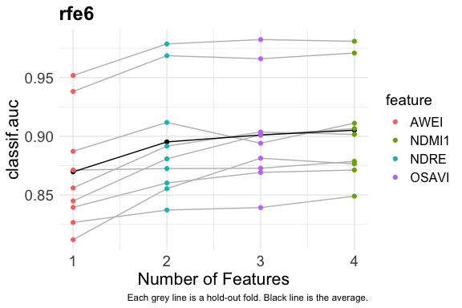

```r
plot_nfeat(rfe6, featureset6)
```

I think these 4 features may be a good final choice. They use complementary info

- AWEI uses green, nir, and swir bands
- NDRE uses nir and red edge
- NDMI1 uses nir and swir
- OSAVI uses nir and red